# Patterns in my Youtube Viewing Habits

## Introduction

An exploration into my YouTube viewing habits, based on data I have collected by logging each video I have watched based on a series of questions.

## Does the way in which I discover videos affect the rating I give it?

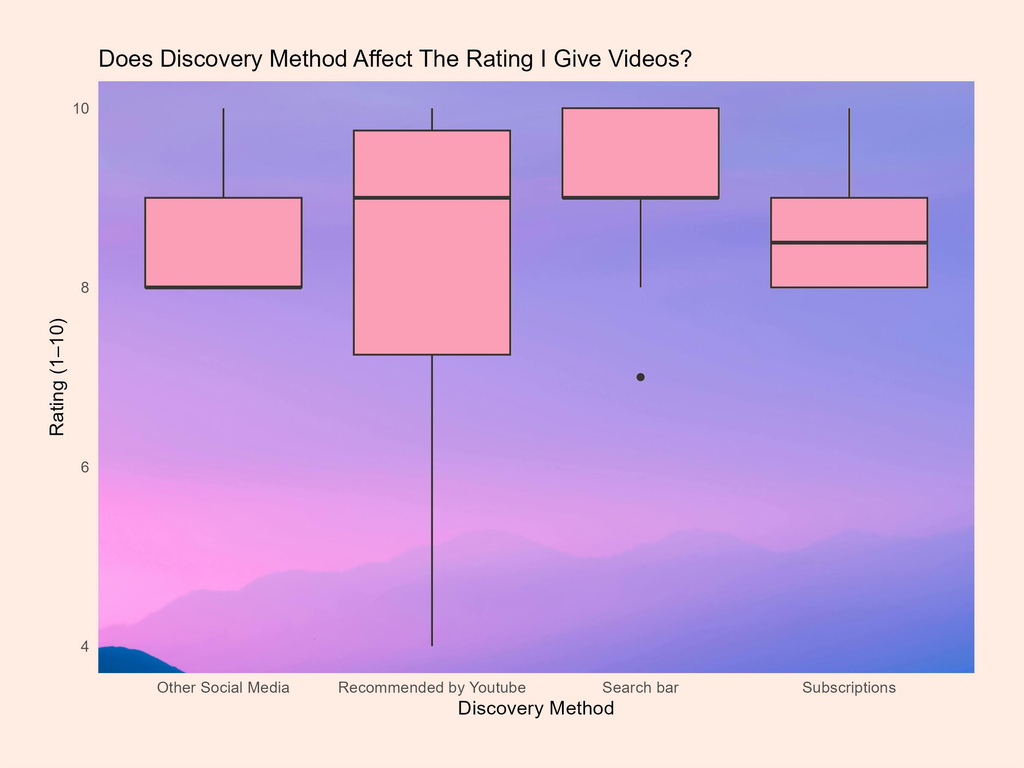

Boxplot showing ratings by discovery method

Here we see that my average rating is typically higher and consistent for YouTube videos I have searched for. It also seems that videos recommended by YouTube tend to be more varied. This does make sense, as videos I have personally sought after, would usually be videos I **want** to watch, while those recommended by YouTube may just peak my interest.

## What are my top 5 most watched categories?

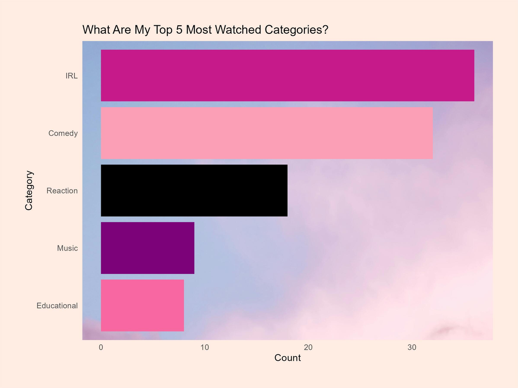

Bar chart of my top 5 categories for YouTube videos

From this plot, I can see that IRL and Comedy are by far my most watched categories. This does make sense, as I feel as though IRL and Comedy tend to overlap with a lot of other categories.

## What are my watching patterns across the day?

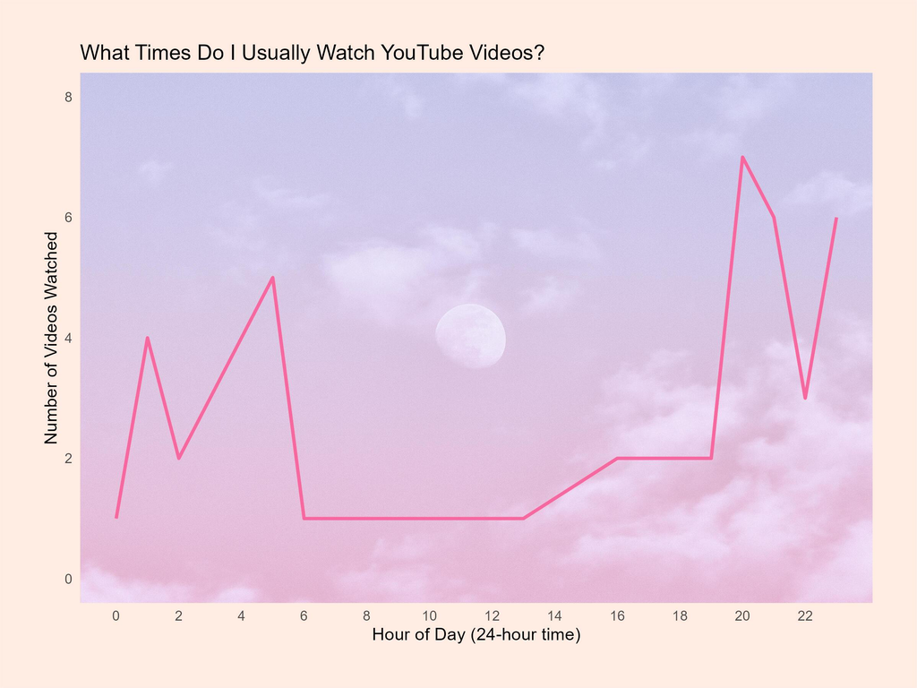

From the plot above, we can see that most of my viewing occurs from 8pm, all the way to 6am. It seems my most active hours, are 8pm, 9pm, and 11pm.

## Does watching a video in its entirety result in a higher rating?

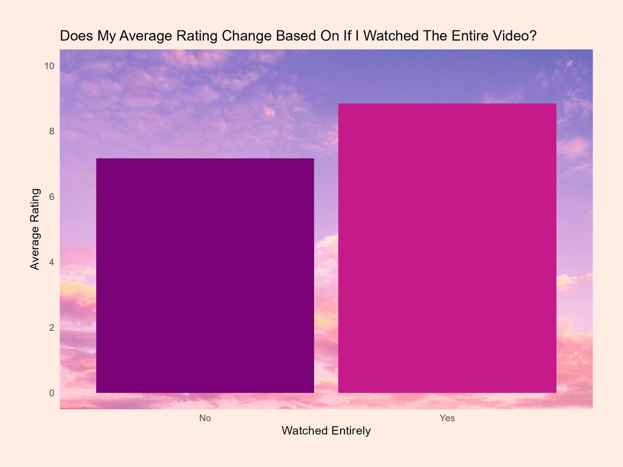

Bar chart of average rating by if I watched the entire video

Videos that I watch entirely have an average rating of 8.8, while those I don’t watch fully average 7.2. This makes sense, as I would be more likely to finish a video I am more engaged with.

## Conclusion

Overall, this analysis into my viewing habits has revealed some clear trends. Firstly I tend to watch IRL and Comedy videos the most, this could likely be because they overlap with multiple interest and that they are the videos that resonate with me the most. Secondly videos I actively search for generally get higher ratings, which tells me I tend to enjoy videos I seek out, over those recommended by YouTube.

A surprising statistic is the hours I typically watch videos the most, being from 8 PM, to 6 AM. This timing could reflect YouTube’s role in both a reward and distraction during my study hours. I also tend to use videos as background noise during these sessions.

Lastly, (not as surprising) is that videos I watch in full tend to receive better ratings, meaning completing videos correlates directly with higher engagement, and satisfaction.